# Predictor Variable Conceptual Domains

Classification of ~2,500 predictors into thematic categories

```r
library(dplyr)
library(tidyr)
library(ggplot2)
library(knitr)
library(kableExtra)
library(targets)
library(here)

# ── Results source toggle ──────────────────────────────────────────────────
# Switch between fast and full results:
TARGETS_STORE <- here("_targets")
# TARGETS_STORE <- here("_targets_full")  # uncomment for full results

source(here("R", "conceptual_ablation.R"))
mapping <- load_conceptual_domains()
```

## Overview

The micronutrient prediction models draw on **10 data sources** containing over **2,500 candidate predictor variables**. These variables span diverse domains — from satellite-derived soil chemistry to household survey responses about breastfeeding practices. Understanding *what* the model uses, and *which thematic areas contribute most*, is critical for interpretability and policy relevance.

This document classifies every predictor variable into a **two-level conceptual hierarchy**:

- **Level 1** (broad thematic area): e.g., “Child Nutrition”, “Climate”, “Soil”
- **Level 2** (specific topic): e.g., “Breastfeeding”, “Precipitation”, “Soil micronutrients”

Variables that cannot be confidently classified from their prefix patterns are marked “Unknown”.

## Data Source → Conceptual Domain Mapping

```r
source_summary <- mapping |>
  group_by(data_source) |>
  summarise(
    n_patterns = n(),
    level1_domains = paste(sort(unique(level1_domain)), collapse = ", "),
    .groups = "drop"
  ) |>
  arrange(desc(n_patterns))

kable(source_summary,
      col.names = c("Data Source", "# Patterns", "Level-1 Domains"),
      caption = "Data sources and the conceptual domains they contribute to") |>
  kable_styling(bootstrap_options = c("striped", "hover"),
                full_width = FALSE, font_size = 11)
```

Data sources and the conceptual domains they contribute to

| Data Source | # Patterns | Level-1 Domains |
| --- | --- | --- |
| DHS | 66 | Adult Health, Adult Nutrition, Child Health, Child Mortality, Child Nutrition, Child Protection, Domestic Violence, Education, Employment, Family Planning, Female Genital Cutting, Fertility, HIV/AIDS,… |
| MICS | 47 | Child Nutrition, Education, Household Characteristics, Malaria, Survey Characteristics, Survey Indicators, Water and Sanitation |
| GEE | 31 | Agriculture, Climate, Demographics, Environment, Infrastructure, Soil |
| IHME | 27 | Adult Nutrition, Child Mortality, Child Nutrition, Development, Education, Environment, Fertility, Health and Development, Health System, Infectious Disease, Nutrition, Water and Sanitation |
| MAP | 10 | Child Mortality, Household Characteristics, Infectious Disease, Infrastructure, Malaria Prevention |
| FSEC | 9 | Food Security |
| WFP | 2 | Food Security |
| DERIVED | 1 | Missingness Indicators |
| FLUNET | 1 | Infectious Disease |
| LSMS | 1 | Household Characteristics |

## Level-1 Conceptual Domains

```r
l1_summary <- mapping |>
  filter(match_type == "prefix") |>
  group_by(level1_domain) |>
  summarise(
    n_patterns   = n(),
    data_sources = paste(sort(unique(data_source)), collapse = ", "),
    .groups      = "drop"
  ) |>
  arrange(desc(n_patterns))

kable(l1_summary,
      col.names = c("Level-1 Domain", "# Variable Patterns", "Data Sources"),
      caption = "Level-1 conceptual domains across all data sources") |>
  kable_styling(bootstrap_options = c("striped", "hover"),
                full_width = FALSE, font_size = 11)
```

Level-1 conceptual domains across all data sources

| Level-1 Domain | # Variable Patterns | Data Sources |
| --- | --- | --- |
| Household Characteristics | 40 | DHS, LSMS, MAP, MICS |
| Water and Sanitation | 16 | DHS, IHME, MICS |
| Child Nutrition | 11 | DHS, IHME, MICS |
| Fertility | 11 | DHS, IHME |
| Soil | 11 | GEE |
| Food Security | 10 | FSEC, WFP |
| Infectious Disease | 10 | FLUNET, IHME, MAP |
| Child Health | 7 | DHS |
| Environment | 7 | GEE, IHME |
| Infrastructure | 7 | GEE, MAP |
| Survey Characteristics | 7 | DHS, MICS |
| Adult Nutrition | 5 | DHS, IHME |
| Climate | 5 | GEE |
| Nutrition | 5 | IHME |
| Child Mortality | 4 | DHS, IHME, MAP |
| Education | 4 | DHS, IHME, MICS |
| Malaria | 4 | DHS, MICS |
| Reproductive Health | 4 | DHS |
| HIV/AIDS | 3 | DHS |
| Malaria Prevention | 3 | MAP |
| Agriculture | 2 | GEE |
| Demographics | 2 | GEE |
| Development | 2 | IHME |
| Health System | 2 | IHME |
| Adult Health | 1 | DHS |
| Child Protection | 1 | DHS |
| Domestic Violence | 1 | DHS |
| Employment | 1 | DHS |
| Family Planning | 1 | DHS |
| Female Genital Cutting | 1 | DHS |
| Health and Development | 1 | IHME |
| Marriage | 1 | DHS |
| Missingness Indicators | 1 | DERIVED |
| Sexual Activity | 1 | DHS |
| Survey Indicators | 1 | MICS |
| Women's Empowerment | 1 | DHS |

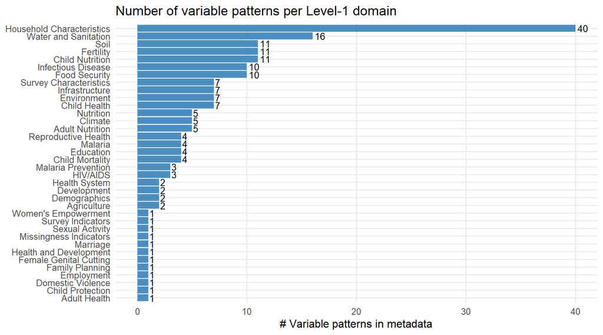

```r
ggplot(l1_summary, aes(x = reorder(level1_domain, n_patterns), y = n_patterns)) +
  geom_col(fill = "#2c7bb6", alpha = 0.85) +
  geom_text(aes(label = n_patterns), hjust = -0.2, size = 3.5) +
  coord_flip() +
  labs(
    title = "Number of variable patterns per Level-1 domain",
    x = NULL, y = "# Variable patterns in metadata"
  ) +
  theme_minimal(base_size = 12) +
  theme(panel.grid.minor = element_blank())
```

## Level-2 Conceptual Domains

```r
l2_summary <- mapping |>
  filter(match_type == "prefix") |>
  group_by(level1_domain, level2_domain) |>
  summarise(
    n_patterns   = n(),
    data_sources = paste(sort(unique(data_source)), collapse = ", "),
    .groups      = "drop"
  ) |>
  arrange(level1_domain, desc(n_patterns))

kable(l2_summary,
      col.names = c("Level-1", "Level-2", "# Patterns", "Data Sources"),
      caption = "Full two-level conceptual hierarchy") |>
  kable_styling(bootstrap_options = c("striped", "hover"),
                full_width = FALSE, font_size = 10) |>
  collapse_rows(columns = 1, valign = "top")
```

Full two-level conceptual hierarchy

| Level-1 | Level-2 | # Patterns | Data Sources |
| --- | --- | --- | --- |
| Adult Health | Adult health | 1 | DHS |
| Adult Nutrition | Adult nutrition (other) | 1 | DHS |
|  | Anemia (women) | 1 | DHS |
|  | Micronutrient intake | 1 | DHS |
|  | Nutritional status (women) | 1 | DHS |
|  | Overweight/obesity | 1 | IHME |
| Agriculture | Cropland | 2 | GEE |
| Child Health | ARI | 1 | DHS |
|  | Birth weight | 1 | DHS |
|  | Child health (other) | 1 | DHS |
|  | Diarrhea | 1 | DHS |
|  | Fever | 1 | DHS |
|  | Sanitation behavior | 1 | DHS |
|  | Vaccinations | 1 | DHS |
| Child Mortality | Child mortality | 1 | MAP |
|  | Childhood mortality | 1 | DHS |
|  | Neonatal mortality | 1 | IHME |
|  | Under-5 mortality | 1 | IHME |
| Child Nutrition | Anemia (children) | 1 | DHS |
|  | Breastfeeding | 1 | DHS |
|  | Child nutrition (other) | 1 | DHS |
|  | Child nutritional status | 1 | DHS |
|  | Infant feeding | 1 | DHS |
|  | Iodized salt | 1 | DHS |
|  | Micronutrient supplementation | 1 | DHS |
|  | Salt iodization | 1 | MICS |
|  | Stunting | 1 | IHME |
|  | Underweight | 1 | IHME |
|  | Wasting | 1 | IHME |
| Child Protection | Child protection | 1 | DHS |

[output cut: 114 more lines]

## Applied Classification: Ghana Child Iron

The following shows the actual variable classification applied to the Ghana child iron deficiency model (the best-performing outcome).

```r
# Try to load the Ghana child_iron model Xvars
sl_fit <- tryCatch(tar_read(sl_fit_ghana_child_iron, store = TARGETS_STORE), error = function(e) NULL)

if (!is.null(sl_fit) && !is.null(sl_fit$cont_fit)) {
  xvars <- sl_fit$cont_fit$Xvars

  l1_class <- classify_variables(xvars, mapping)
  l2_class <- classify_variables_l2(xvars, mapping)

  cat(sprintf("Total model variables: %d\n", length(xvars)))
  cat(sprintf("Classified: %d (%.0f%%)\n",
              sum(l1_class != "Unknown"),
              100 * mean(l1_class != "Unknown")))
  cat(sprintf("Unknown: %d\n", sum(l1_class == "Unknown")))
} else {
  cat("Ghana child_iron model not available — run targets pipeline first.\n")
  l1_class <- NULL
}
```

```
Total model variables: 298
Classified: 289 (97%)
Unknown: 9
```

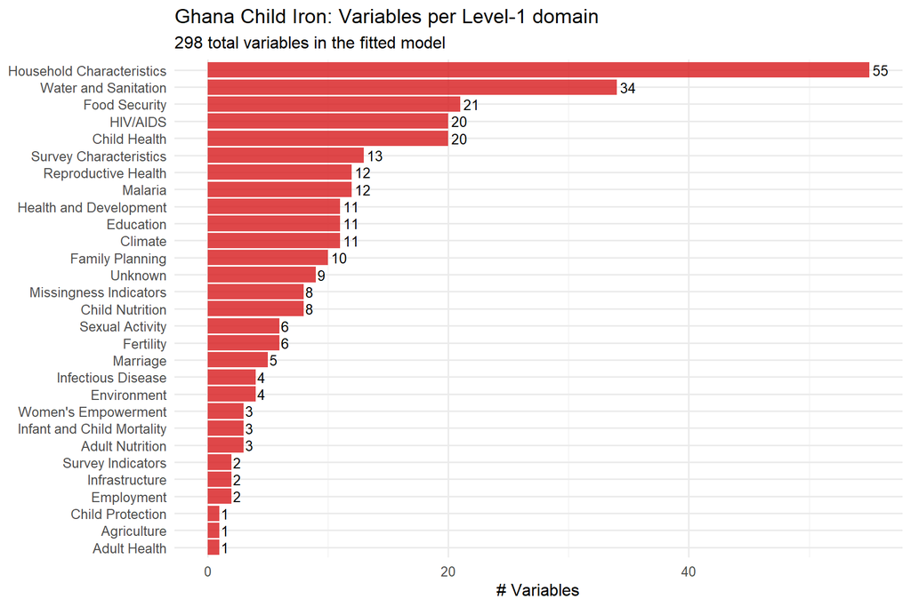

```r
if (!is.null(l1_class)) {
  l1_df <- data.frame(domain = l1_class) |>
    count(domain) |>
    arrange(desc(n))

  ggplot(l1_df, aes(x = reorder(domain, n), y = n)) +
    geom_col(fill = "#d7191c", alpha = 0.8) +
    geom_text(aes(label = n), hjust = -0.2, size = 3.5) +
    coord_flip() +
    labs(
      title = "Ghana Child Iron: Variables per Level-1 domain",
      subtitle = sprintf("%d total variables in the fitted model", length(xvars)),
      x = NULL, y = "# Variables"
    ) +
    theme_minimal(base_size = 12)
}
```

### Cross-tabulation: Data Source × Level-1 Domain

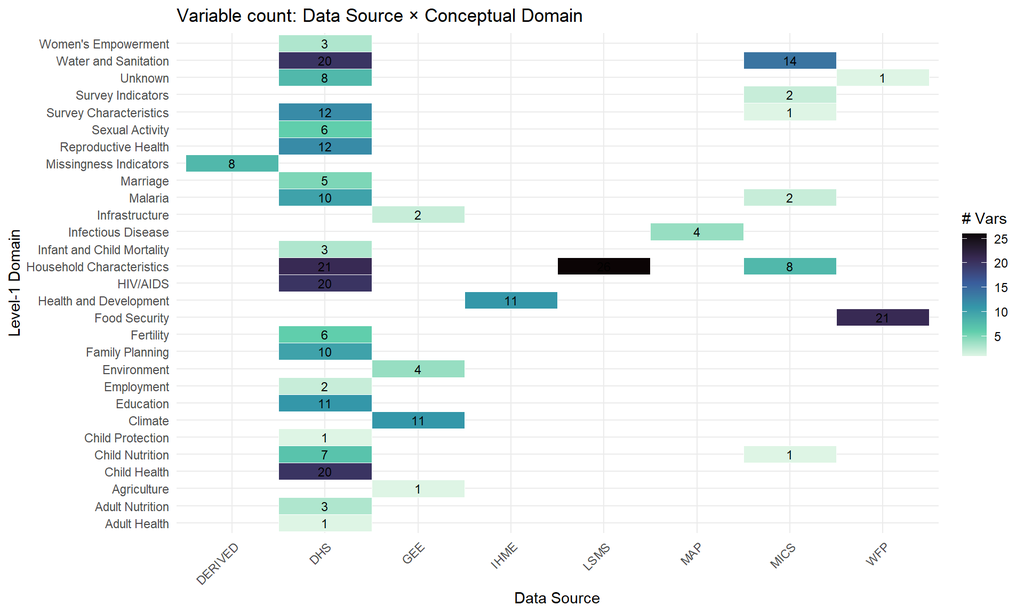

```r
if (!is.null(l1_class)) {
  # Determine data source from variable prefix
  get_source <- function(v) {
    if (grepl("^dhs\\d{4}_", v)) return("DHS")
    if (grepl("^mics_", v))      return("MICS")
    if (grepl("^ihme_", v))      return("IHME")
    if (grepl("^MAP_", v))       return("MAP")
    if (grepl("^gee_", v))       return("GEE")
    if (grepl("^fsec_", v))      return("FSEC")
    if (grepl("^wfp_|^nearest_market", v)) return("WFP")
    if (grepl("^flunet_", v))    return("FLUNET")
    if (grepl("^lsms_", v))      return("LSMS")
    if (grepl("^missing_", v))   return("DERIVED")
    return("Other")
  }

  cross_df <- data.frame(
    variable = xvars,
    source   = sapply(xvars, get_source, USE.NAMES = FALSE),
    domain   = l1_class,
    stringsAsFactors = FALSE
  )

  cross_tab <- cross_df |>
    count(source, domain) |>
    pivot_wider(names_from = source, values_from = n, values_fill = 0)

  kable(cross_tab, caption = "Variables by Data Source × Level-1 Domain") |>
    kable_styling(bootstrap_options = c("striped", "hover"),
                  full_width = FALSE, font_size = 10)

  # Heatmap
  cross_heat <- cross_df |> count(source, domain)

  ggplot(cross_heat, aes(x = source, y = domain, fill = n)) +
    geom_tile(color = "white") +
    geom_text(aes(label = ifelse(n > 0, n, "")), size = 3) +
    scale_fill_viridis_c(option = "mako", direction = -1, na.value = "grey95") +
    labs(
      title = "Variable count: Data Source × Conceptual Domain",
      x = "Data Source", y = "Level-1 Domain", fill = "# Vars"
    ) +
    theme_minimal(base_size = 11) +
    theme(axis.text.x = element_text(angle = 45, hjust = 1))
}
```

## Conceptual Domain Permutation Importance

Two complementary analyses measure each domain’s importance:

- **Permute-one** (marginal importance): Shuffle one domain at a time while keeping all others intact. The AUC drop measures how much that domain contributes *on top of everything else*. Domains with redundant signal (correlated with other domains) will show small drops even if individually informative.
- **Leave-one-in** (standalone contribution): Shuffle *all other* domains and keep only one domain intact. The resulting AUC measures how well that domain predicts *on its own*. A domain can have high standalone AUC but low marginal importance if other domains carry overlapping signal.

Both analyses use cross-validated predictions (`predict_fold("validation")`) to avoid overfitting bias. Confidence intervals are empirical 2.5th–97.5th percentiles across permutation replicates.

```r
perm_l1_file <- here::here("results", "conceptual_ablation", "ghana_child_iron_level1.csv")
loi_l1_file  <- here::here("results", "conceptual_ablation", "ghana_child_iron_leave_one_in_l1.csv")
perm_l2_file <- here::here("results", "conceptual_ablation", "ghana_child_iron_level2.csv")

perm_l1 <- if (file.exists(perm_l1_file)) read.csv(perm_l1_file) else NULL
loi_l1  <- if (file.exists(loi_l1_file))  read.csv(loi_l1_file)  else NULL
perm_l2 <- if (file.exists(perm_l2_file)) read.csv(perm_l2_file) else NULL

has_results <- !is.null(perm_l1)
has_loi     <- !is.null(loi_l1)
```

### Permute-one: Marginal domain importance

Shuffling each domain’s variables breaks its relationship with the outcome. Domains whose removal causes the largest AUC drop are contributing the most marginal signal.

```r
if (has_results) {
  kable(perm_l1 |>
          arrange(desc(auc_drop)) |>
          select(domain, n_vars, baseline_auc, perm_auc, auc_drop, auc_drop_lo, auc_drop_hi) |>
          mutate(across(where(is.numeric), ~ round(., 4))),
        col.names = c("Domain", "# Vars", "Baseline AUC", "Permuted AUC",
                       "AUC Drop", "Drop Lo", "Drop Hi"),
        caption = "Level-1 marginal importance (permute-one): ranked by AUC drop") |>
    kable_styling(bootstrap_options = c("striped", "hover"),
                  full_width = FALSE, font_size = 10)
} else {
  cat("Run `source('scripts/test_conceptual_ablation.R')` first.\n")
}
```

Level-1 marginal importance (permute-one): ranked by AUC drop

| Domain | # Vars | Baseline AUC | Permuted AUC | AUC Drop | Drop Lo | Drop Hi |
| --- | --- | --- | --- | --- | --- | --- |
| Food Security | 19 | 0.7751 | 0.7535 | 0.0216 | 0.0141 | 0.0292 |
| Climate | 11 | 0.7751 | 0.7625 | 0.0126 | 0.0051 | 0.0203 |
| Health and Development | 11 | 0.7751 | 0.7703 | 0.0048 | 0.0015 | 0.0081 |
| Environment | 6 | 0.7751 | 0.7709 | 0.0041 | 0.0009 | 0.0080 |
| Water and Sanitation | 33 | 0.7751 | 0.7711 | 0.0040 | -0.0006 | 0.0080 |
| Unknown | 6 | 0.7751 | 0.7711 | 0.0039 | -0.0004 | 0.0075 |
| Household Characteristics | 56 | 0.7751 | 0.7714 | 0.0037 | -0.0004 | 0.0075 |
| Infectious Disease | 6 | 0.7751 | 0.7714 | 0.0036 | 0.0006 | 0.0074 |
| Infrastructure | 2 | 0.7751 | 0.7722 | 0.0029 | 0.0007 | 0.0053 |
| Missingness Indicators | 9 | 0.7751 | 0.7722 | 0.0029 | 0.0010 | 0.0049 |
| Family Planning | 9 | 0.7751 | 0.7729 | 0.0022 | -0.0013 | 0.0077 |
| Child Health | 23 | 0.7751 | 0.7733 | 0.0017 | -0.0014 | 0.0044 |
| HIV/AIDS | 21 | 0.7751 | 0.7734 | 0.0017 | -0.0012 | 0.0043 |
| Survey Indicators | 2 | 0.7751 | 0.7739 | 0.0012 | 0.0002 | 0.0021 |
| Education | 12 | 0.7751 | 0.7739 | 0.0012 | -0.0019 | 0.0038 |
| Malaria | 16 | 0.7751 | 0.7742 | 0.0008 | -0.0006 | 0.0023 |
| Child Nutrition | 7 | 0.7751 | 0.7743 | 0.0008 | -0.0003 | 0.0020 |
| Reproductive Health | 10 | 0.7751 | 0.7744 | 0.0007 | -0.0026 | 0.0031 |
| Infant and Child Mortality | 2 | 0.7751 | 0.7747 | 0.0004 | -0.0006 | 0.0015 |
| Women's Empowerment | 3 | 0.7751 | 0.7748 | 0.0002 | -0.0005 | 0.0012 |
| Fertility | 5 | 0.7751 | 0.7753 | -0.0002 | -0.0014 | 0.0007 |
| Employment | 4 | 0.7751 | 0.7753 | -0.0002 | -0.0010 | 0.0005 |
| Sexual Activity | 6 | 0.7751 | 0.7753 | -0.0002 | -0.0014 | 0.0006 |
| Adult Health | 1 | 0.7751 | 0.7754 | -0.0004 | -0.0011 | 0.0003 |
| Marriage | 3 | 0.7751 | 0.7755 | -0.0004 | -0.0011 | 0.0002 |
| Adult Nutrition | 2 | 0.7751 | 0.7755 | -0.0005 | -0.0012 | 0.0002 |
| Survey Characteristics | 17 | 0.7751 | 0.7755 | -0.0005 | -0.0018 | 0.0006 |

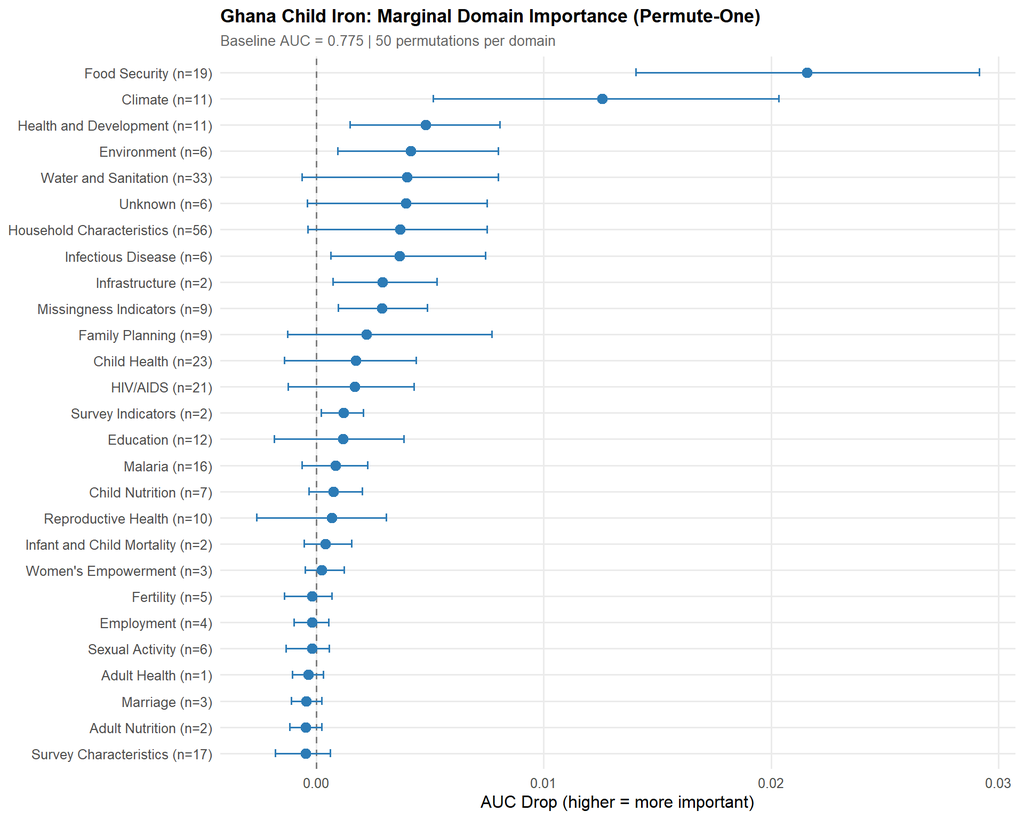

```r
if (has_results) {
  # Ranked forest plot with CI bars
  df <- perm_l1 |>
    arrange(auc_drop) |>
    mutate(label = sprintf("%s (n=%d)", domain, n_vars),
           label = factor(label, levels = label))

  ggplot(df, aes(x = auc_drop, y = label)) +
    geom_vline(xintercept = 0, linetype = "dashed", color = "grey50") +
    geom_errorbarh(aes(xmin = auc_drop_lo, xmax = auc_drop_hi),
                   height = 0.3, color = "#2c7bb6", linewidth = 0.7) +
    geom_point(size = 3, color = "#2c7bb6") +
    labs(
      title = "Ghana Child Iron: Marginal Domain Importance (Permute-One)",
      subtitle = sprintf("Baseline AUC = %.3f | %d permutations per domain",
                         df$baseline_auc[1], df$n_perm_valid[1]),
      x = "AUC Drop (higher = more important)",
      y = NULL
    ) +
    theme_minimal(base_size = 12) +
    theme(
      plot.title    = element_text(face = "bold", size = 13),
      plot.subtitle = element_text(color = "grey40", size = 10),
      panel.grid.minor = element_blank()
    )
}
```

### Leave-one-in: Standalone domain contribution

Keeping only one domain’s variables intact (shuffling all others) shows how well each domain predicts on its own. The blue vertical line marks the full model AUC; the dashed line marks chance (AUC = 0.5).

```r
if (has_loi) {
  kable(loi_l1 |>
          arrange(desc(solo_auc)) |>
          select(domain, n_vars, baseline_auc, solo_auc, solo_auc_lo, solo_auc_hi, recovery_auc) |>
          mutate(across(where(is.numeric), ~ round(., 4)),
                 recovery_pct = sprintf("%.0f%%", recovery_auc * 100)) |>
          select(-recovery_auc),
        col.names = c("Domain", "# Vars", "Baseline AUC", "Solo AUC",
                       "Solo Lo", "Solo Hi", "Recovery"),
        caption = "Level-1 standalone contribution (leave-one-in): ranked by solo AUC") |>
    kable_styling(bootstrap_options = c("striped", "hover"),
                  full_width = FALSE, font_size = 10)
} else {
  cat("Leave-one-in results not available.\n")
}
```

Level-1 standalone contribution (leave-one-in): ranked by solo AUC

| Domain | # Vars | Baseline AUC | Solo AUC | Solo Lo | Solo Hi | Recovery |
| --- | --- | --- | --- | --- | --- | --- |
| Climate | 11 | 0.7751 | 0.5664 | 0.5432 | 0.6024 | 24% |
| Food Security | 19 | 0.7751 | 0.5352 | 0.5007 | 0.5719 | 13% |
| Family Planning | 9 | 0.7751 | 0.5328 | 0.4833 | 0.5708 | 12% |
| Unknown | 6 | 0.7751 | 0.5319 | 0.4920 | 0.5703 | 12% |
| Water and Sanitation | 33 | 0.7751 | 0.5268 | 0.4770 | 0.5702 | 10% |
| Household Characteristics | 56 | 0.7751 | 0.5238 | 0.4916 | 0.5561 | 9% |
| HIV/AIDS | 21 | 0.7751 | 0.5210 | 0.4905 | 0.5509 | 8% |
| Child Health | 23 | 0.7751 | 0.5205 | 0.4887 | 0.5576 | 7% |
| Reproductive Health | 10 | 0.7751 | 0.5198 | 0.4839 | 0.5581 | 7% |
| Education | 12 | 0.7751 | 0.5198 | 0.4785 | 0.5648 | 7% |
| Survey Characteristics | 17 | 0.7751 | 0.5191 | 0.4837 | 0.5491 | 7% |
| Health and Development | 11 | 0.7751 | 0.5183 | 0.4899 | 0.5482 | 7% |
| Infant and Child Mortality | 2 | 0.7751 | 0.5177 | 0.4883 | 0.5512 | 6% |
| Infrastructure | 2 | 0.7751 | 0.5175 | 0.4880 | 0.5529 | 6% |
| Adult Health | 1 | 0.7751 | 0.5173 | 0.4891 | 0.5505 | 6% |
| Missingness Indicators | 9 | 0.7751 | 0.5169 | 0.4872 | 0.5522 | 6% |
| Child Nutrition | 7 | 0.7751 | 0.5168 | 0.4920 | 0.5422 | 6% |
| Environment | 6 | 0.7751 | 0.5164 | 0.4820 | 0.5480 | 6% |
| Employment | 4 | 0.7751 | 0.5155 | 0.4984 | 0.5425 | 6% |
| Malaria | 16 | 0.7751 | 0.5154 | 0.4925 | 0.5444 | 6% |
| Fertility | 5 | 0.7751 | 0.5152 | 0.4895 | 0.5503 | 6% |
| Sexual Activity | 6 | 0.7751 | 0.5143 | 0.4907 | 0.5374 | 5% |
| Infectious Disease | 6 | 0.7751 | 0.5142 | 0.4920 | 0.5475 | 5% |
| Marriage | 3 | 0.7751 | 0.5142 | 0.4867 | 0.5555 | 5% |
| Adult Nutrition | 2 | 0.7751 | 0.5121 | 0.4906 | 0.5428 | 4% |
| Survey Indicators | 2 | 0.7751 | 0.5114 | 0.4848 | 0.5425 | 4% |
| Women's Empowerment | 3 | 0.7751 | 0.5103 | 0.4833 | 0.5504 | 4% |

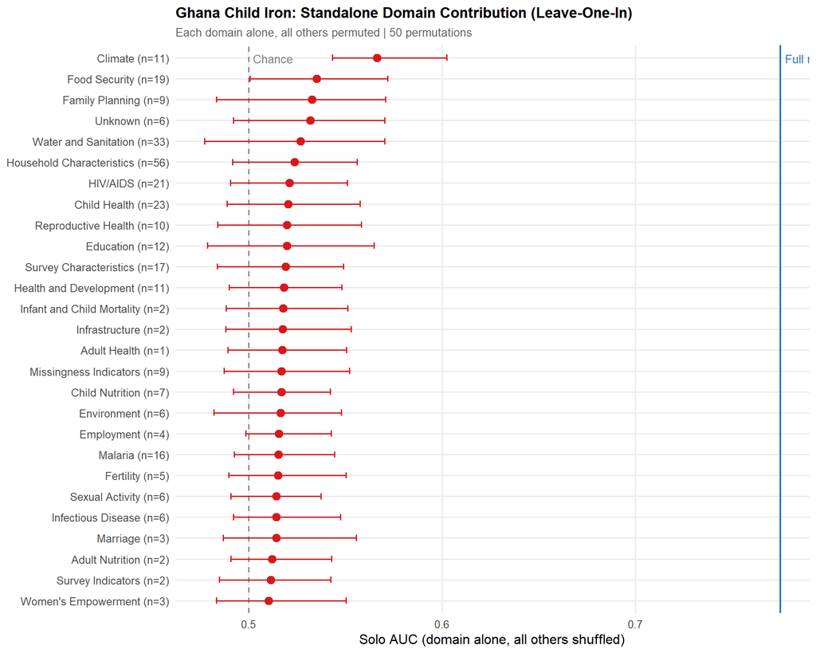

```r
if (has_loi) {
  baseline_val <- loi_l1$baseline_auc[1]

  df <- loi_l1 |>
    arrange(solo_auc) |>
    mutate(label = sprintf("%s (n=%d)", domain, n_vars),
           label = factor(label, levels = label))

  ggplot(df, aes(x = solo_auc, y = label)) +
    geom_vline(xintercept = 0.5, linetype = "dashed", color = "grey50") +
    geom_vline(xintercept = baseline_val, linetype = "solid",
               color = "#2c7bb6", linewidth = 0.8) +
    geom_errorbarh(aes(xmin = solo_auc_lo, xmax = solo_auc_hi),
                   height = 0.3, color = "#d7191c", linewidth = 0.7) +
    geom_point(size = 3, color = "#d7191c") +
    annotate("text", x = baseline_val, y = Inf,
             label = sprintf("Full model (%.3f)", baseline_val),
             hjust = -0.05, vjust = 2, color = "#2c7bb6", size = 3.5) +
    annotate("text", x = 0.5, y = Inf, label = "Chance",
             hjust = -0.1, vjust = 2, color = "grey50", size = 3.5) +
    labs(
      title = "Ghana Child Iron: Standalone Domain Contribution (Leave-One-In)",
      subtitle = sprintf("Each domain alone, all others permuted | %d permutations",
                         max(df$n_perm_valid, na.rm = TRUE)),
      x = "Solo AUC (domain alone, all others shuffled)",
      y = NULL
    ) +
    theme_minimal(base_size = 12) +
    theme(
      plot.title    = element_text(face = "bold", size = 13),
      plot.subtitle = element_text(color = "grey40", size = 10),
      panel.grid.minor = element_blank()
    )
}
```

### Side-by-side comparison

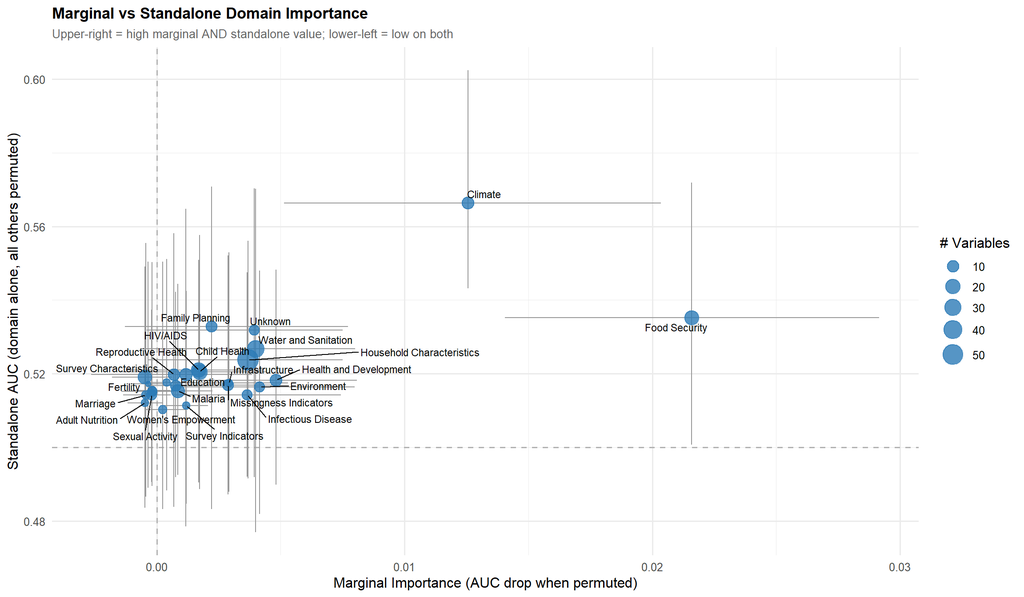

```r
if (has_results && has_loi) {
  # Merge both analyses by domain
  comparison <- merge(
    perm_l1 |> select(domain, n_vars, auc_drop, auc_drop_lo, auc_drop_hi),
    loi_l1 |> select(domain, solo_auc, solo_auc_lo, solo_auc_hi, recovery_auc),
    by = "domain"
  )

  # Scatter: marginal importance vs standalone contribution
  ggplot(comparison, aes(x = auc_drop, y = solo_auc)) +
    geom_hline(yintercept = 0.5, linetype = "dashed", color = "grey70") +
    geom_vline(xintercept = 0, linetype = "dashed", color = "grey70") +
    geom_errorbar(aes(ymin = solo_auc_lo, ymax = solo_auc_hi),
                  width = 0, color = "grey60", linewidth = 0.4) +
    geom_errorbarh(aes(xmin = auc_drop_lo, xmax = auc_drop_hi),
                   height = 0, color = "grey60", linewidth = 0.4) +
    geom_point(aes(size = n_vars), color = "#2c7bb6", alpha = 0.8) +
    ggrepel::geom_text_repel(aes(label = domain), size = 3, max.overlaps = 20) +
    scale_size_continuous(range = c(2, 8), name = "# Variables") +
    labs(
      title = "Marginal vs Standalone Domain Importance",
      subtitle = "Upper-right = high marginal AND standalone value; lower-left = low on both",
      x = "Marginal Importance (AUC drop when permuted)",
      y = "Standalone AUC (domain alone, all others permuted)"
    ) +
    theme_minimal(base_size = 12) +
    theme(
      plot.title    = element_text(face = "bold", size = 13),
      plot.subtitle = element_text(color = "grey40", size = 10)
    )
}
```

### Level-2 detail (if available)

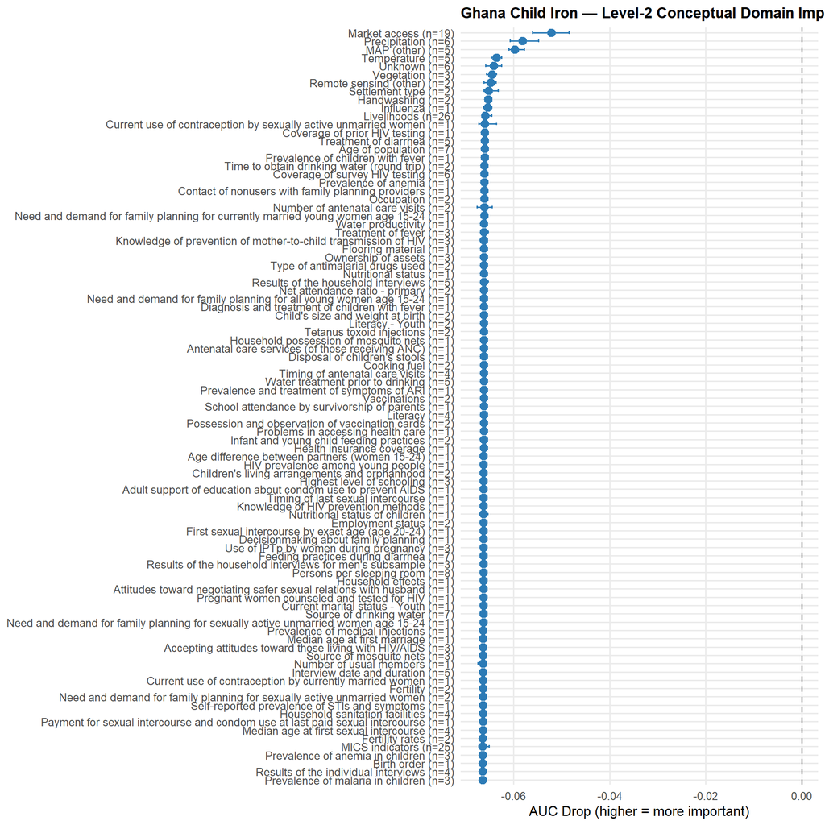

```r
if (!is.null(perm_l2)) {
  p2 <- plot_conceptual_forest(
    perm_l2,
    title = "Ghana Child Iron — Level-2 Conceptual Domain Importance"
  )
  print(p2)
} else {
  cat("Level-2 analysis not run. Set `RUN_LEVEL2 <- TRUE` in the test script.\n")
}
```

## Unknown Variables

Variables classified as “Unknown” could not be matched to any pattern in the metadata. These should be reviewed and added to `metadata/variable_conceptual_domains.csv`.

```r
if (!is.null(l1_class)) {
  unknowns <- names(l1_class[l1_class == "Unknown"])
  if (length(unknowns) > 0) {
    # Group by apparent prefix
    unk_df <- data.frame(variable = unknowns, stringsAsFactors = FALSE) |>
      mutate(prefix = sub("_.*", "_", variable)) |>
      count(prefix) |>
      arrange(desc(n))

    kable(unk_df,
          col.names = c("Prefix Pattern", "# Variables"),
          caption = "Unknown variables grouped by prefix") |>
      kable_styling(bootstrap_options = c("striped", "hover"),
                    full_width = FALSE, font_size = 11)
  } else {
    cat("All variables successfully classified!")
  }
}
```

Unknown variables grouped by prefix

| Prefix Pattern | # Variables |
| --- | --- |
| dhs2014_ | 4 |
| dhs2016_ | 2 |
| dhs2017_ | 2 |
| nearest_ | 1 |